# HW5_TS

Curtis Zhuang

2021/5/2

#### **Question 1:**

#### Load the condmilk.rda dataset and split it into a training dataset (1971/1 – 1979/12) and a test dataset (1980/1 – 1980/12)

```r
load('condmilk.rda')

## Split
train <- condmilk[1:108]
test <- condmilk[109:120]

## Convert to ts
train_milk <- ts(train, start = c(1971, 1), frequency = 12)
test_milk <- ts(test, start = c(1980, 1), frequency = 12)
```

#### **Question 2:**

#### Plot the training dataset. Is Box-Cox transformation necessary for this data?

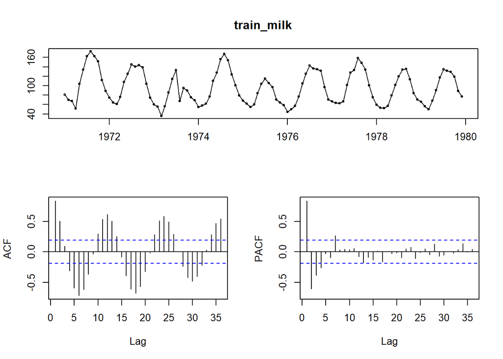

```r
tsdisplay(train_milk)
```

```r
### From the graph we see that variance change overtime so we do need transformations
lambda <- BoxCox.lambda(train_milk)
lambda
```

```
## [1] -0.3944237
```

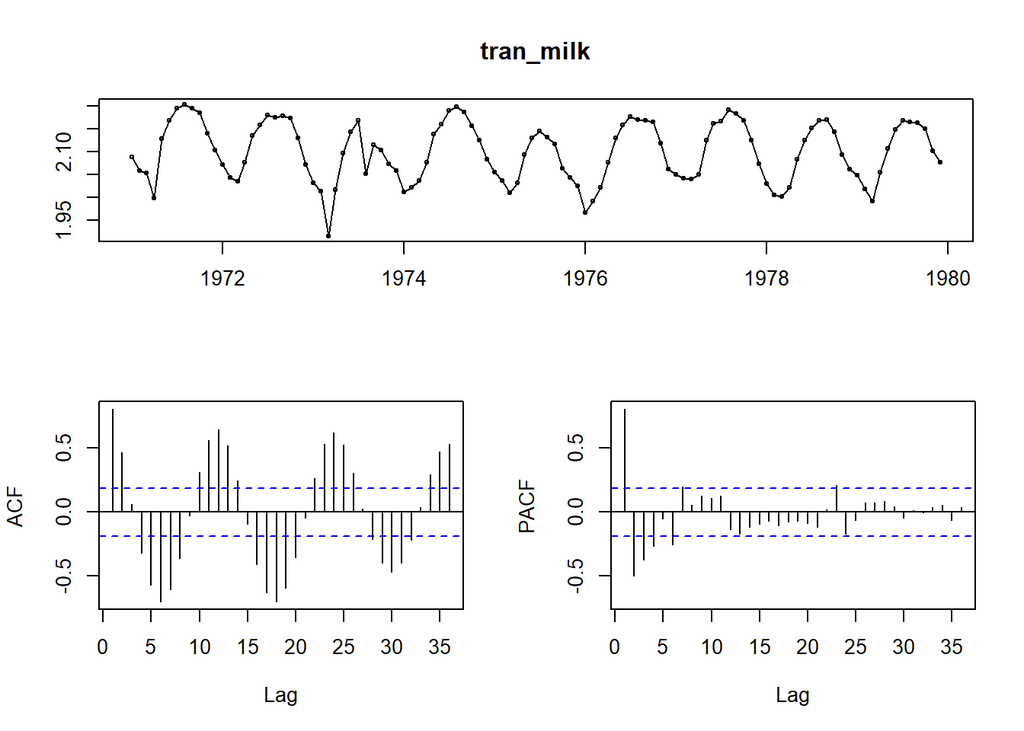

```r
# do transformation based on the best lambda
tran_milk <- BoxCox(train_milk, lambda = lambda)

tsdisplay(tran_milk)
```

**By looking at the ts plot, we see that the variance is flucutaing from year to year so we need to do a transformation. And we performed boxcox based on the auto lambda value.**

#### **Question 3:**

#### Is the training dataset stationary? If not, find an appropriate differencing which yields seasonal and trend stationary training dataset. Plot the ACF and PACF to determine if the detrended and deseasonalized time series is stationary.

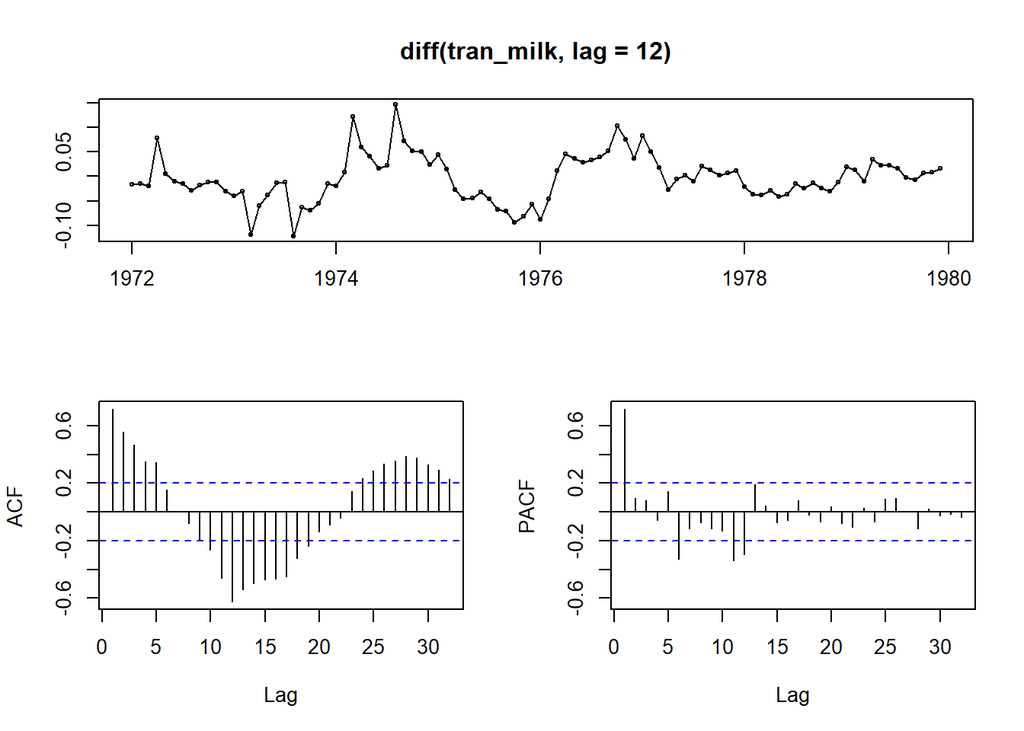

```r
tsdisplay(diff(tran_milk, lag = 12))
```

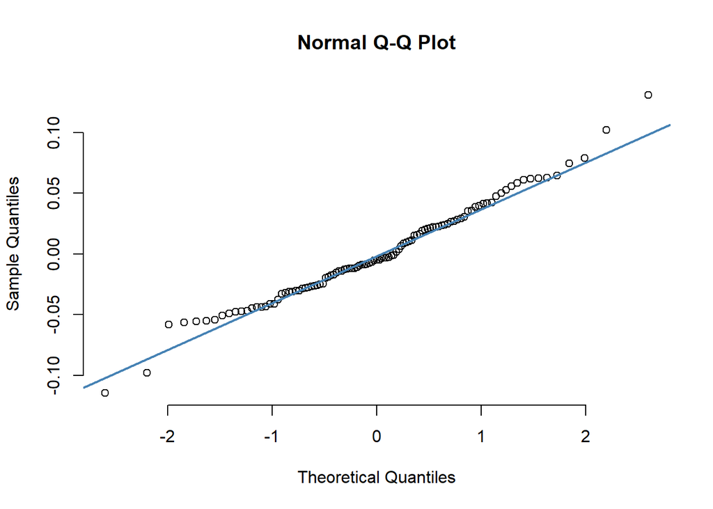

```r
qqnorm(diff(tran_milk), pch = 1, frame = FALSE)
qqline(diff(tran_milk), col = "steelblue", lwd = 2)
```

```r
# Adf test
adf.test(diff(tran_milk))
```

```
##
##  Augmented Dickey-Fuller Test
##
## data:  diff(tran_milk)
## Dickey-Fuller = -6.1914, Lag order = 4, p-value = 0.01
## alternative hypothesis: stationary
```

```r
## KPSS test
kpss.test(diff(tran_milk), null = c("Level", "Trend"), lshort = TRUE)
```

```
##
##  KPSS Test for Level Stationarity
##
## data:  diff(tran_milk)
## KPSS Level = 0.01593, Truncation lag parameter = 4, p-value = 0.1
```

#### **Question 4:**

#### Build two 𝐴𝑅𝐼𝑀𝐴(𝑝,𝑑,𝑞)(𝑃,𝑄,𝐷)𝑠 models using the training dataset and auto.arima() function.

• Model 1: Let the auto.arima() function determine the best order of non-seasonal and seasonal differencing.

Report the resulting 𝑝,𝑑,𝑞,𝑃,𝐷,𝑄,𝑠 and the coefficients values for all cases and compare their AICc and BIC values.

```r
model_1 <- auto.arima(train_milk, lambda = 'auto', seasonal = TRUE, trace = TRUE)
```

```
##
##  ARIMA(2,0,2)(1,1,1)[12] with drift         : Inf
##  ARIMA(0,0,0)(0,1,0)[12] with drift         : -311.3349
##  ARIMA(1,0,0)(1,1,0)[12] with drift         : -401.2044
##  ARIMA(0,0,1)(0,1,1)[12] with drift         : Inf
##  ARIMA(0,0,0)(0,1,0)[12]                    : -312.929
##  ARIMA(1,0,0)(0,1,0)[12] with drift         : -377.2686
##  ARIMA(1,0,0)(2,1,0)[12] with drift         : -408.6123
##  ARIMA(1,0,0)(2,1,1)[12] with drift         : Inf
##  ARIMA(1,0,0)(1,1,1)[12] with drift         : Inf
##  ARIMA(0,0,0)(2,1,0)[12] with drift         : -366.0954
##  ARIMA(2,0,0)(2,1,0)[12] with drift         : -408.3202
##  ARIMA(1,0,1)(2,1,0)[12] with drift         : -408.3404
##  ARIMA(0,0,1)(2,1,0)[12] with drift         : -393.598
##  ARIMA(2,0,1)(2,1,0)[12] with drift         : -407.0607
##  ARIMA(1,0,0)(2,1,0)[12]                    : -410.3663
##  ARIMA(1,0,0)(1,1,0)[12]                    : -402.8434
##  ARIMA(1,0,0)(2,1,1)[12]                    : Inf
##  ARIMA(1,0,0)(1,1,1)[12]                    : Inf
##  ARIMA(0,0,0)(2,1,0)[12]                    : -366.347
##  ARIMA(2,0,0)(2,1,0)[12]                    : -410.159
##  ARIMA(1,0,1)(2,1,0)[12]                    : -410.1937
##  ARIMA(0,0,1)(2,1,0)[12]                    : -394.7657
##  ARIMA(2,0,1)(2,1,0)[12]                    : -408.8728
##
##  Best model: ARIMA(1,0,0)(2,1,0)[12]
```

```r
model_1
```

```
## Series: train_milk
## ARIMA(1,0,0)(2,1,0)[12]
## Box Cox transformation: lambda= -0.3944247
##
## Coefficients:
##         ar1     sar1     sar2
##       0.638  -0.7483  -0.3904
## s.e.  0.081   0.1120   0.1145
##
## sigma^2 estimated as 0.000705:  log likelihood=209.4
## AIC=-410.81   AICc=-410.37   BIC=-400.55
```

**For model 1, p = 1, d = 0, q = 0, P = 2, D = 1, Q = 0, s = 12. All the coefficients are listed above and AICc = -410.37 and BIC = -400.55.**

• Model 2: Set the order of seasonal-differencing 𝑑 to 1 and 𝐷 to 1.

```r
model_2 <- auto.arima(train_milk, lambda = 'auto', seasonal = TRUE, trace = TRUE, D = 1, d = 1)
```

```
##
##  ARIMA(2,1,2)(1,1,1)[12]                    : Inf
##  ARIMA(0,1,0)(0,1,0)[12]                    : -362.727
##  ARIMA(1,1,0)(1,1,0)[12]                    : -391.0752
##  ARIMA(0,1,1)(0,1,1)[12]                    : Inf
##  ARIMA(1,1,0)(0,1,0)[12]                    : -365.4785
##  ARIMA(1,1,0)(2,1,0)[12]                    : -396.4089
##  ARIMA(1,1,0)(2,1,1)[12]                    : Inf
##  ARIMA(1,1,0)(1,1,1)[12]                    : Inf
##  ARIMA(0,1,0)(2,1,0)[12]                    : -390.0317
##  ARIMA(2,1,0)(2,1,0)[12]                    : -396.3982
##  ARIMA(1,1,1)(2,1,0)[12]                    : -399.581
##  ARIMA(1,1,1)(1,1,0)[12]                    : -392.5245
##  ARIMA(1,1,1)(2,1,1)[12]                    : Inf
##  ARIMA(1,1,1)(1,1,1)[12]                    : Inf
##  ARIMA(0,1,1)(2,1,0)[12]                    : -399.1336
##  ARIMA(2,1,1)(2,1,0)[12]                    : -399.3577
##  ARIMA(1,1,2)(2,1,0)[12]                    : -399.4472
##  ARIMA(0,1,2)(2,1,0)[12]                    : -397.642
##  ARIMA(2,1,2)(2,1,0)[12]                    : -398.2506
##
##  Best model: ARIMA(1,1,1)(2,1,0)[12]
```

```r
model_2
```

```
## Series: train_milk
## ARIMA(1,1,1)(2,1,0)[12]
## Box Cox transformation: lambda= -0.3944247
##
## Coefficients:
##          ar1      ma1     sar1     sar2
##       0.6164  -0.9566  -0.7541  -0.3823
## s.e.  0.1108   0.0638   0.1171   0.1152
##
## sigma^2 estimated as 0.0007327:  log likelihood=205.13
## AIC=-400.26   AICc=-399.58   BIC=-387.49
```

**For model 2, p = 1, d = 1, q = 1, P = 2, D = 1, Q = 0, s = 12. All the coefficients are listed and AICc = -399.58 and BIC = -387.49.**

#### **Question 5:**

#### Plot the residuals ACF of both models from part 4 and use the Ljung-Box Test with lag 12 to verify your conclusion.

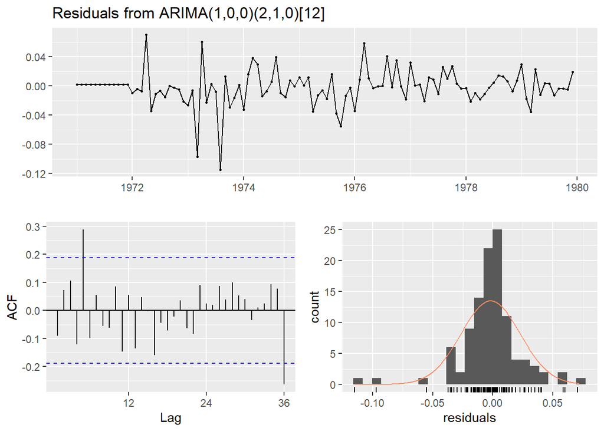

```
##
##  Ljung-Box test
##
## data:  Residuals from ARIMA(1,0,0)(2,1,0)[12]
## Q* = 28.775, df = 19, p-value = 0.06961
##
## Model df: 3.   Total lags used: 22
```

```r
checkresiduals(model_1)
```

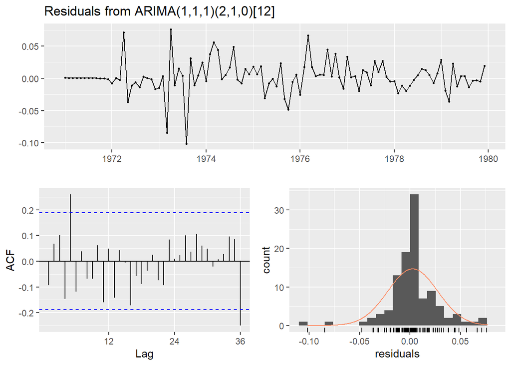

```
##
##  Ljung-Box test
##
## data:  Residuals from ARIMA(1,1,1)(2,1,0)[12]
## Q* = 30.036, df = 18, p-value = 0.0371
##
## Model df: 4.   Total lags used: 22
```

```r
checkresiduals(model_2)
```

```r
shapiro.test(model_1$residuals)
```

```
##
##  Shapiro-Wilk normality test
##
## data:  model_1$residuals
## W = 0.88672, p-value = 1.497e-07
```

```r
shapiro.test(model_2$residuals)
```

```
##
##  Shapiro-Wilk normality test
##
## data:  model_2$residuals
## W = 0.90136, p-value = 7.333e-07
```

**From Shapiro-Wilk test, we see that both has p < 0.05 which we can then reject our null hypothesis that residual is normal. From Ljung-Box test both have p value on border so we will use the result from S-W test and it is not normally distributed.**

#### **Question 6:**

#### Use both models from part 4 and the h-period argument in the forecast() function to forecast each month of 1980 (i.e., Jan, Feb, …, Dec.) Plot the test dataset and forecasted values.

```r
h <- 12

### Model 1

model_forecast_1 <-forecast(model_1, h)

model_forecast_1
```

```
##          Point Forecast     Lo 80     Hi 80    Lo 95     Hi 95
## Jan 1980       66.22500  55.76564  79.63602 51.14517  88.30545
## Feb 1980       58.98855  48.58856  72.77517 44.09831  81.94331
## Mar 1980       56.08265  45.88258  69.74452 41.50951  78.91043
## Apr 1980       64.03721  51.62906  81.03279 46.38930  92.65768
## May 1980       90.72684  70.83039 119.37072 62.70288 139.83597
## Jun 1980      115.38437  87.92565 156.44692 76.98482 186.79556
## Jul 1980      129.11790  97.21487 177.74472 84.65909 214.30669
## Aug 1980      142.78325 106.32790 199.33209 92.14126 242.53314
## Sep 1980      139.09424 103.87104 193.48789 90.12456 234.87357
## Oct 1980      122.70343  92.85954 167.82332 81.05231 201.50025
## Nov 1980       91.51776  71.29542 120.72805 63.05293 141.65963
## Dec 1980       73.77375  58.60108  95.03746 52.29156 109.87472
```

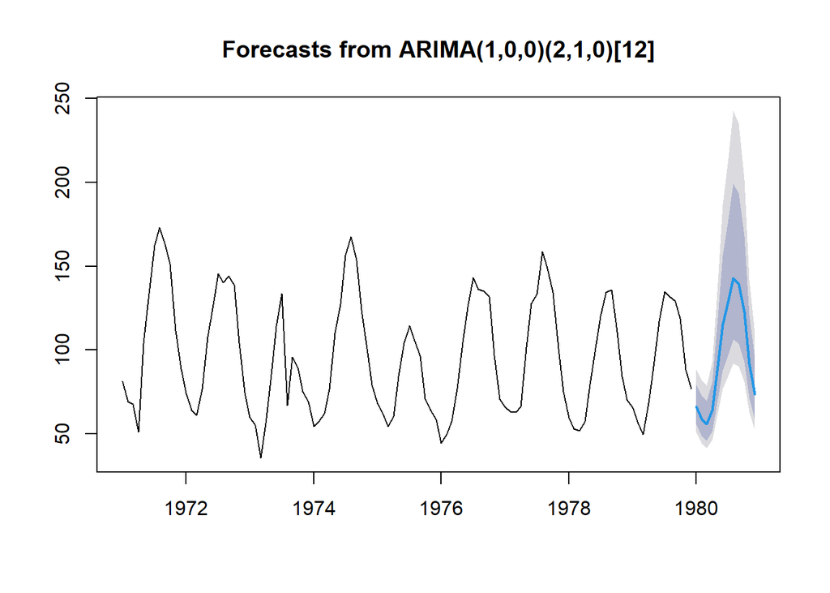

```r
plot(model_forecast_1)
```

```r
### Model 2

model_forecast_2 <-forecast(model_2, h)

model_forecast_2
```

```
##          Point Forecast     Lo 80     Hi 80    Lo 95     Hi 95
## Jan 1980       65.99932  55.40838  79.64072 50.74441  88.49291
## Feb 1980       58.75518  48.14345  72.93500 43.58659  82.42918
## Mar 1980       55.90742  45.39572  70.14962 40.92408  79.80002
## Apr 1980       63.78624  50.91343  81.69248 45.53350  94.10570
## May 1980       90.33112  69.58144 120.83756 61.22161 143.04393
## Jun 1980      114.90379  86.12418 159.08550 74.84980 192.52173
## Jul 1980      128.76439  95.12365 181.62150 82.13916 222.47856
## Aug 1980      142.45688 103.85894 204.40768 89.16076 253.24081
## Sep 1980      138.91107 101.43515 198.90633 87.14101 246.08568
## Oct 1980      122.41774  90.58568 172.29953 78.27837 210.76256
## Nov 1980       91.30566  69.63809 123.66312 60.99695 147.54827
## Dec 1980       73.65888  57.32007  97.29992 50.66796 114.26631
```

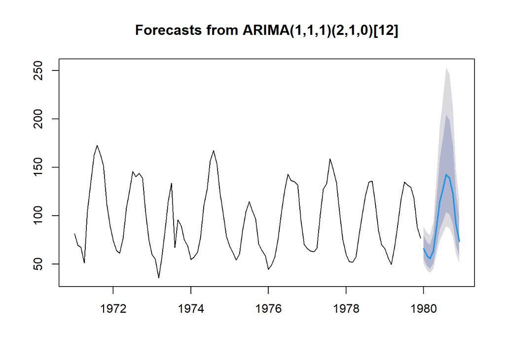

```r
plot(model_forecast_2)
```

#### **Question 7:**

#### Compare the forecast with the actual test data by calculating the Mean Absolute Percentage Error (MAPE) and Mean Squared Error (MSE). Which model is better to forecast the Manufacturer’s Stocks for each month of 1980 (i.e., Jan, Feb, …, Dec)?

```r
MSE_1 <- sum((model_forecast_1$mean - test_milk)^2) / 12

MSE_1
```

```
## [1] 303.4648
```

```r
MAPE_1 <- sum(abs((test_milk - model_forecast_1$mean) / model_forecast_1$mean))/12

MAPE_1
```

```
## [1] 0.1868011
```

```r
accuracy(model_forecast_1, test_milk)
```

```
##                      ME     RMSE       MAE       MPE      MAPE      MASE
## Training set -0.8181605 12.50303  8.048068 -2.059967  9.287228 0.4136761
## Test set     -1.2429125 17.42024 15.278808 -1.640571 18.474942 0.7853409
##                     ACF1 Theil's U
## Training set 0.007322755        NA
## Test set     0.806698756  1.272007
```

**For model 1, the MSE is equal to 303.4648 and MAPE equal to 0.1868 from calculation. The MAPE value is a little bit different if we use the value from the accuracy function and it will be 0.1847. This may be caused by the difference in calculation method and is not a big issue.**

```r
# Model 2

MSE_2 <- sum((model_forecast_2$mean - test_milk)^2) / 12

MSE_2
```

```
## [1] 303.4596
```

```r
MAPE_2 <- sum(abs((test_milk - model_forecast_2$mean) / model_forecast_2$mean))/12

MAPE_2
```

```
## [1] 0.1882279
```

```r
accuracy(model_forecast_2, test_milk)
```

```
##                      ME     RMSE       MAE        MPE      MAPE      MASE
## Training set  1.4092497 12.21211  7.787317  0.5090038  8.902121 0.4002733
## Test set     -0.9731403 17.42009 15.302630 -1.3569380 18.510907 0.7865654
##                     ACF1 Theil's U
## Training set 0.006682278        NA
## Test set     0.806918820  1.275601
```

**For model 2, MSE is equal to 303.4596 and MAPE is equal to 0.1882 or 0.1851 for the two methods.**

#### **Question 8:**

#### Forecast each month of 1980 (i.e., Jan, Feb, …, Dec.) using the seasonal naïve forecast method. Plot the test dataset and forecasted values, and compare the forecast with the actual test data by calculating the Mean Absolute Percentage Error (MAPE) and Mean Squared Error (MSE).

```r
model_SNaive <- snaive(train_milk, h)

MSE_S <- sum((model_SNaive$mean - test)^2) / 12

MSE_S
```

```
## [1] 277.8286
```

```r
MAPE_S <- sum(abs((test - model_SNaive$mean) / model_SNaive$mean))/12

MAPE_S
```

```
## [1] 0.1900364
```

```r
accuracy(model_SNaive, test_milk)
```

```
##                     ME     RMSE      MAE        MPE     MAPE      MASE
## Training set -2.398333 25.99516 19.45500 -5.7705450 21.71705 1.0000000
## Test set      0.692500 16.66819 14.20083  0.1351056 17.97548 0.7299323
##                   ACF1 Theil's U
## Training set 0.8007662        NA
## Test set     0.7060731  1.298065
```

**For the model using seasonal naive method, MSE is equal to 277.8286 and MAPE is equal to 0.1900.**